# HCV

- Download Dataset
- Data Preprocessing
- Exploratory Data Analysis
- Train/Val/Test Split
- Neural Network
- Gradient Boosted Decision Tree
- Random Forest
- Ensemble Model
- Evaluate Performance

```python
import numpy as np
import pandas as pd
import xgboost as xgb
import tensorflow as tf
from tensorflow import keras
import matplotlib.pyplot as plt
from tensorflow.keras import layers
from sklearn.neighbors import KNeighborsClassifier
from sklearn.model_selection import train_test_split
from sklearn.preprocessing import Normalizer, LabelEncoder
from sklearn.metrics import confusion_matrix, classification_report
```

# Download Dataset

Download HCV Dataset from UCI Machine Learning Repository

https://archive.ics.uci.edu/ml/datasets/HCV+data

```python
df = pd.read_csv('https://archive.ics.uci.edu/ml/machine-learning-databases/00571/hcvdat0.csv')
```

```python
df.head()
```

|  | Unnamed: 0 | Category | Age | Sex | ALB | ALP | ALT | AST | BIL | CHE | CHOL | CREA | GGT | PROT |
| --- | --- | --- | --- | --- | --- | --- | --- | --- | --- | --- | --- | --- | --- | --- |
| 0 | 1 | 0=Blood Donor | 32 | m | 38.5 | 52.5 | 7.7 | 22.1 | 7.5 | 6.93 | 3.23 | 106.0 | 12.1 | 69.0 |
| 1 | 2 | 0=Blood Donor | 32 | m | 38.5 | 70.3 | 18.0 | 24.7 | 3.9 | 11.17 | 4.80 | 74.0 | 15.6 | 76.5 |
| 2 | 3 | 0=Blood Donor | 32 | m | 46.9 | 74.7 | 36.2 | 52.6 | 6.1 | 8.84 | 5.20 | 86.0 | 33.2 | 79.3 |
| 3 | 4 | 0=Blood Donor | 32 | m | 43.2 | 52.0 | 30.6 | 22.6 | 18.9 | 7.33 | 4.74 | 80.0 | 33.8 | 75.7 |
| 4 | 5 | 0=Blood Donor | 32 | m | 39.2 | 74.1 | 32.6 | 24.8 | 9.6 | 9.15 | 4.32 | 76.0 | 29.9 | 68.7 |

Target variable is the Category. What are the possible values?

- "0=Blood Donor"
- "1=Hepatitis"
- "2=Fibrosis"
- "3=Cirrhosis"
- "0s=suspect Blood Donor"

# Data Preprocessing

I will not use the "0s=suspect Blood Donor" target.

```python
df['Category'].value_counts()
```

```
0=Blood Donor             533
3=Cirrhosis                30
1=Hepatitis                24
2=Fibrosis                 21
0s=suspect Blood Donor      7
Name: Category, dtype: int64
```

```python
df = df[df['Category'] != '0s=suspect Blood Donor']
```

Change the values in the Sex field to be 1 or 0 instead of "f" or "m".

```python
df['Sex'] = np.where(df['Sex']=='f', 1, 0)
```

# Exploratory Data Analysis

Plot some of the feature distributions among the different classes

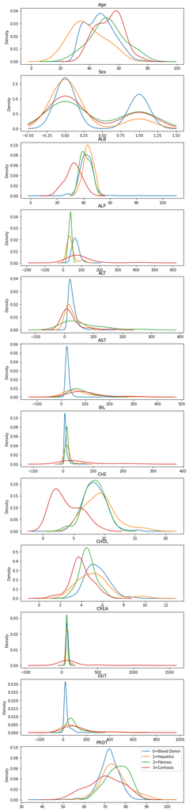

```python
X_cols = df.columns[2:]
fig, axs = plt.subplots(12, 1, figsize=(8,40))
for i, col in enumerate(X_cols):
    df.groupby('Category')[col].plot(kind='kde', ax=axs[i], title=col)
plt.legend()
plt.show()
```

# Train / Val / Test Split

I will make the target a 4-dimensional one-hot vector

```python
y = pd.get_dummies(df['Category']).values
```

```python
X = df[X_cols]
```

Split into training, validation, and test sets.

```python
X_train, X_test, y_train, y_test = train_test_split(
    X, y, test_size=0.20, random_state=100
)

X_train, X_val, y_train, y_val = train_test_split(
    X_train, y_train, test_size=0.125, random_state=100
)
```

Fill in missing feature values with the mean feature value of the training set

```python
training_means = X_train.mean(axis=0).to_dict()

X_train.fillna(training_means, inplace=True)
X_val.fillna(training_means, inplace=True)
X_test.fillna(training_means, inplace=True)
```

Normalize the features based on the values in the training set. Apply transformation to training, validation, and test sets.

```python
transformer = Normalizer().fit(X_train)
X_train = transformer.transform(X_train)
X_val = transformer.transform(X_val)
X_test = transformer.transform(X_test)
```

# Neural Network

Define, compile, and train feed-forward neural network

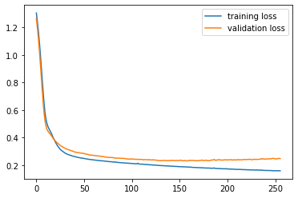

```python
inputs = keras.Input(shape=(len(X_cols),), name='Inputs')
x = layers.Dense(10, activation='relu', name='Dense_1')(inputs)
x = layers.Dense(10, activation='relu', name='Dense_2')(x)
outputs = layers.Dense(4, activation='softmax', name='Outputs')(x)
model = keras.Model(inputs=inputs, outputs=outputs)

model.compile(
    optimizer='adam',
    loss='categorical_crossentropy',
    metrics=['accuracy']
)

history = model.fit(
    X_train,
    y_train,
    batch_size=32,
    epochs=256,
    validation_data=(X_val, y_val),
    verbose=0
)

plt.plot(history.history['loss'], label='training loss')
plt.plot(history.history['val_loss'], label='validation loss')
plt.legend()
plt.show()
```

Evaluate performance on test set

```python
results = model.evaluate(X_test, y_test)
print(f'Test loss: {results[0]}. Test accuracy {results[1]}.')
```

```
Test loss: 0.26302483677864075. Test accuracy 0.9098360538482666.
```

```python
label_dict = {
    0: 'Blood Donor',
    1: 'Hepatitis',
    2: 'Fibrosis',
    3: 'Cirrhosis'
}

y_pred = np.argmax(model.predict(X_test), axis=1)
y_pred_labels = np.vectorize(label_dict.get)(y_pred)
y_test_labels = np.vectorize(label_dict.get)(np.argmax(y_test, axis=1))
print(classification_report(y_test_labels, y_pred_labels, list(label_dict.values())))
```

```
              precision    recall  f1-score   support

 Blood Donor       0.94      0.99      0.96       107
   Hepatitis       1.00      0.12      0.22         8
    Fibrosis       0.40      0.40      0.40         5
   Cirrhosis       0.67      1.00      0.80         2

    accuracy                           0.91       122
   macro avg       0.75      0.63      0.60       122
weighted avg       0.92      0.91      0.89       122
```

# Gradient Boosted Decision Tree

Define and train a gradient boosted decision tree

```python
gbt = xgb.XGBClassifier(
    objective='multi:softmax',
    n_estimators=100,
)
```

```python
# xgboost expects a label encoded target variable
y_train_le = np.where(y_train==1)[1]
y_val_le = np.where(y_val==1)[1]
y_test_le = np.where(y_test==1)[1]

gbt.fit(
    X_train, y_train_le,
    #eval_set=[(X_train, y_train_le), (X_val, y_val_le)],
    eval_metric='logloss',
    verbose=False
)
```

```
XGBClassifier(base_score=0.5, booster='gbtree', colsample_bylevel=1,
              colsample_bynode=1, colsample_bytree=1, gamma=0, gpu_id=-1,
              importance_type='gain', interaction_constraints='',
              learning_rate=0.300000012, max_delta_step=0, max_depth=6,
              min_child_weight=1, missing=nan, monotone_constraints='()',
              n_estimators=100, n_jobs=0, num_parallel_tree=1,
              objective='multi:softprob', random_state=0, reg_alpha=0,
              reg_lambda=1, scale_pos_weight=None, subsample=1,
              tree_method='exact', validate_parameters=1, verbosity=None)
```

Evaluate performance on test set

```python
print(f'Test accuracy {gbt.score(X_test, y_test_le)}.')
```

```
Test accuracy 0.9426229508196722.
```

Confusion matrix

```python
y_pred = gbt.predict(X_test)
# Confusion matrix whose i-th row and j-th column entry indicates the number of
# samples with true label being i-th class and prediced label being j-th class.
confusion_matrix(np.argmax(y_test, axis=1), y_pred)
```

```
array([[106,   0,   0,   1],
       [  1,   4,   3,   0],
       [  1,   0,   3,   1],
       [  0,   0,   0,   2]], dtype=int64)
```

Convert target from label-encoded back to text and print classification report. XGBoost model performed better.

```python
label_dict = {
    0: 'Blood Donor',
    1: 'Hepatitis',
    2: 'Fibrosis',
    3: 'Cirrhosis'
}

y_pred_labels = np.vectorize(label_dict.get)(y_pred)
y_test_labels = np.vectorize(label_dict.get)(np.argmax(y_test, axis=1))
print(classification_report(y_test_labels, y_pred_labels, list(label_dict.values())))
```

```
              precision    recall  f1-score   support

 Blood Donor       0.98      0.99      0.99       107
   Hepatitis       1.00      0.50      0.67         8
    Fibrosis       0.50      0.60      0.55         5
   Cirrhosis       0.50      1.00      0.67         2

    accuracy                           0.94       122
   macro avg       0.75      0.77      0.72       122
weighted avg       0.96      0.94      0.94       122
```

# Random Forest

```python
from sklearn.ensemble import RandomForestClassifier

rf = RandomForestClassifier(
    criterion='entropy',
    n_estimators=10,
    max_depth=5,
    random_state=100,
    n_jobs=-1
)


rf.fit(X_train, y_train)
```

```
RandomForestClassifier(criterion='entropy', max_depth=5, n_estimators=10,
                       n_jobs=-1, random_state=100)
```

```python
y_pred_rf = np.argmax(rf.predict(X_test), axis=1)
y_pred_rf_labels = np.vectorize(label_dict.get)(y_pred_rf)
print(classification_report(y_test_labels, y_pred_rf_labels, list(label_dict.values())))
```

```
              precision    recall  f1-score   support

 Blood Donor       0.92      1.00      0.96       107
   Hepatitis       1.00      0.25      0.40         8
    Fibrosis       1.00      0.20      0.33         5
   Cirrhosis       0.67      1.00      0.80         2

    accuracy                           0.92       122
   macro avg       0.90      0.61      0.62       122
weighted avg       0.93      0.92      0.89       122
```

```python
print(y_pred_rf.shape)
y_pred_rf_proba = np.asarray(rf.predict_proba(X_test))[:, :, 1].T
print(y_pred_rf_proba.shape)
```

```
(122,)
(122, 4)
```

```python
y_pred_rf_proba[:5, :]
```

```
array([[0.54032738, 0.33392857, 0.05      , 0.07574405],
       [0.99061404, 0.0052193 , 0.00416667, 0.        ],
       [0.99795918, 0.00204082, 0.        , 0.        ],
       [1.        , 0.        , 0.        , 0.        ],
       [0.99794521, 0.00205479, 0.        , 0.        ]])
```

# Ensemble Model

```python
y_pred_gbt_proba = gbt.predict_proba(X_test)
y_pred_ffnn_proba = model.predict(X_test)
y_pred_rf_proba = np.asarray(rf.predict_proba(X_test))[:, :, 1].T

y_pred_avg_proba = (y_pred_gbt_proba + y_pred_ffnn_proba + y_pred_rf_proba)/3
y_pred_avg = np.argmax(y_pred_gbt_proba, axis=1)
```

# Evaluate Performance

```python
y_pred_avg_labels = np.vectorize(label_dict.get)(y_pred_avg)
print(classification_report(y_test_labels, y_pred_avg_labels, list(label_dict.values())))
```

```
              precision    recall  f1-score   support

 Blood Donor       0.98      0.99      0.99       107
   Hepatitis       1.00      0.50      0.67         8
    Fibrosis       0.50      0.60      0.55         5
   Cirrhosis       0.50      1.00      0.67         2

    accuracy                           0.94       122
   macro avg       0.75      0.77      0.72       122
weighted avg       0.96      0.94      0.94       122
```